# hw4

## Analiza danych: Medical Expenditure Panel Survey

Cel: predykcja wydatków związanych z leczeniem  
Katarzyna Lorenc

#### Wartości zmiennej objaśnianej

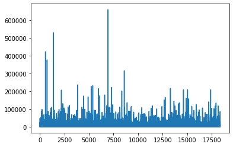

#### Wartości zmiennej objaśnianej po usunięciu obserwacji z wydatkami na leczenie wyższymi niż 125 000

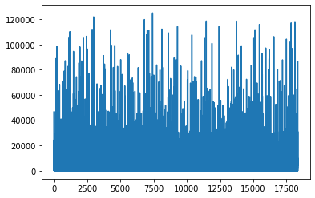

### Model

Wytrenowany model to **GradientBoostingRegressor**.  
Zbiór został podzielony w stosunku 0.9:0.1 odpowiednio na część treningową i testową.  
Poniższe wykresy przedstawiają porównanie wartości predykcji modelu z prawdziwymi wartościami wydatów na leczenie dla zbioru treningowego i testowego.

```
Training R^2: 0.4934790081417796
Test R^2: 0.2349768011698099
```

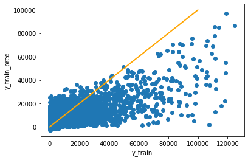

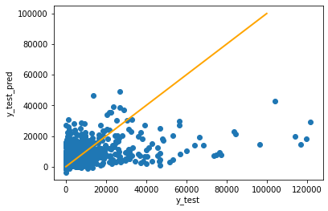

### Selekcja zmiennych

Selekcja zmiennych za pomocą GradientBoostingRegressor. Wytrenowany model to także GradientBoostingRegressor wytrenowany na 10 najbardziej istotnych zmiennych.

```
Training R^2: 0.5840334062623989
Test R^2: 0.16590224466169756
```

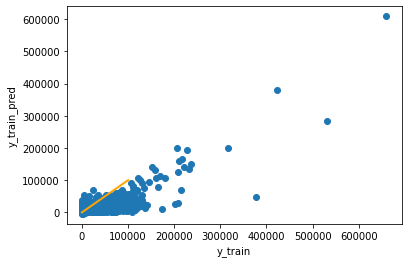

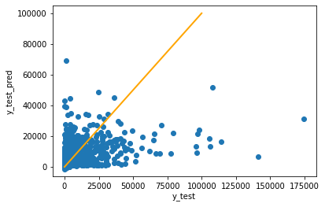

Można zauważyć, że jakość tego modelu jest niższa niż w przypadku braku selekcji. Ze względu na późniejsze wyjaśnienia modeli rozważać będę model mniejszy, mniej dokładny.

### 3) Wyjaśnienie

Poniżej zaprezentowane będą wyjaśnienia za pomocą Ceteris Paribus dla wszystkich zmiennych w modelu, a także wpływ wartości zmiennych określonych za pomocą LIME.  
Zmienne:  
-**WLKLIM31** - Ograniczenie w funkcjonowaniu (fizycznym) [-1 nie dotyczy, 1 tak, 2 nie]  
-**PCS42** - Wynik komponentu fizycznego w ankiecie zdrowotnej (SF-12) [-1 nie dotyczy, wpp. wynik komponentu]  
-**AGE31X** - Wiek  
-**RTHLTH31** - Postrzegany stan zdrowia [-1 nie dotyczy, 1 doskonały, 2 bardzo dobry, 3 dobry, 4 zadowalający, 5 zły]  
-**MCS42** Wynik komponentu umysłowego w ankiecie zdrowotnej (SF-12)[-1 nie dotyczy, wpp. wynik komponentu]  
-**INCOME_M** - całkowity dochód na osobę  
-**K6SUM42** - ogólna ocena samopoczucia [-1 nie dotyczy, 0-24 ocena z poprzednich 30 dni]  
-**ARTHTYPE** - rodzaj artretyzmu [-1 nie dotyczy, 1 reumatoidalne zapalenie stawów, 2 zapalenie kości i stawów]  
-**ACTLIM31** - ograniczenia związane z pracą, obowiązkami domowymi, szkołą [-1 nie dotyczy, 1 tak, 2 nie]  
-**PHQ242** - ogólna ocena samopoczucia [-1 nie dotyczy, 0-6 ocena na podstawie 2 poprzednich tygodni]

#### a) Wyjaśnienie dla zmiennej o najbardziej zaniżonej predykcji

Prawdziwa wartość wydatków na leczenie:

```
174648
```

Wartość predykcji:

```
31404
```

Przy zmianie większość zmiennych, predykcja nie zmieniłaby się znacząco.  
Zmienna, której niska wartość (brak dochodu) ma znaczący negatywny wpływ na wartość wydatków i jednocześnie niejednostajny wykres CeterisParibus to **INCOME_M** czyli wartość dochodu.  
Zmiana dochodu do ponad 90 000 dolarów zwiększyłoby predykcję wydatków z 31 000 do 125 000 dolarów. Nawet przy takiej zmianie wartości istotnej zmiennej model zaniżałby predykcję.

[figure not shown]

```
WARNING:root:Model is unlabeled...
 You can add label using method set_label
```

```
Intercept 7693.654349728594
Prediction_local [23622.62567171]
Right: 31404.45594885613
```

#### b) Wyjaśnienie dla drugiej obserwacji

Prawdziwa wartość wydatków:

```
30698
```

Predykcja wartości wydatków:

```
5583
```

Podobnie jak w powyższym przykładzie, model także zaniża wartość predykcji.  
Dla tej obserwacji zmienna **WLKLIM31** także jest jedną z istotniejszych zmiennych. W tym przypadku jej wartość (czyli brak ograniczeń w funkcjonowaniu fizycznym) negatywnie wpływa na wartość predykcji co wydaje się intuicyjne, tak jak pozytywny wpłw w przypadku ograniczenia fizycznego w poprzednim przykładzie.  
Porównując wykresy Ceteris Paribus dla **WLKLIM31** możemy zauważyć różnicę. Dla powyższej obserwacji zmiana wartości zmiennej nie wpłynie na predykcję, natomiast dla drugiej obserwacji taka zmiana wpłynęłaby na zmianę pozytywnie (ograniczenia w funkcjonowaniu zwiększyłyby predykcję wydatków do 7630 dolarów, a wartość nie dotyczy do 19800 dolarów).  
Inny kształt ma także krzywa dla zmiennej **PHQ242**. W pierwszym przykładzie zmiana oceny samopoczucia nie wpłynęłaby znacząco na predykcję, natomiast w drugim przykładzie zmiana wartości oceny między 3 a 6 spowodowałaby zmianę predykcji z 3 400 do ponad 69 000 dolarów.

[figure not shown]

```
WARNING:root:Model is unlabeled...
 You can add label using method set_label
```

```
Intercept 13976.911167211802
Prediction_local [13355.51216481]
Right: 5582.8626183470105
```

### 5) Regresja grzebietowa

Model regresji grzbietowej na zbiorze danych z dokonaną wcześniej selekcją zmiennych. Po poniższych wykresach można zauważyć, że regresja zdecydowanie zaniża predykcję w przypadku wysokich wydatków.

[figure not shown]

```
Training R^2: 0.11519238150529665
Test R^2: 0.17230351623572926
```

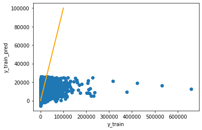

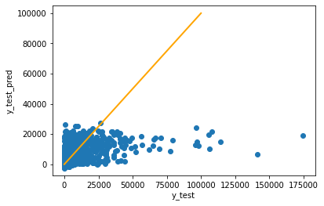

```
WARNING:root:Model is unlabeled...
 You can add label using method set_label
```

```
Intercept 9317.047444647169
Prediction_local [6863.54589002]
Right: 6340.060033636972
```

## Appendix

```python
import pandas as pd
from sklearn.model_selection import train_test_split
from sklearn.metrics import r2_score
from sklearn.ensemble import GradientBoostingRegressor
from sklearn.model_selection import train_test_split
import matplotlib.pyplot as plt
import numpy as np
from ceteris_paribus.explainer import explain
from ceteris_paribus.plots.plots import plot_notebook
from ceteris_paribus.profiles import individual_variable_profile
import lime.lime_tabular
import ceteris_paribus
import warnings
warnings.filterwarnings("ignore")
from ceteris_paribus.plots.plots import plot
from ceteris_paribus.explainer import explain
import matplotlib.pyplot as plt
from sklearn.linear_model import Ridge
import pandas as pd
from sklearn.metrics import classification_report

def train_predict(model, X_train, X_test, y_train, y_test):
    model.fit(X_train, y_train)
    y_pred_train = model.predict(X_train)
    y_pred_test = model.predict(X_test)
    print('Training R^2:', r2_score(y_train, model.predict(X_train)))
    print('Test R^2:', r2_score(y_test, model.predict(X_test)))

    plt.plot([0, 100000], [0, 100000], lw=2, color='orange')
    plt.scatter(y_train, y_pred_train)
    plt.xlabel("y_train")
    plt.ylabel("y_train_pred")
    plt.show()
    plt.plot([0, 100000], [0, 100000], lw=2, color='orange')
    plt.scatter(y_test, y_pred_test)
    plt.xlabel("y_test")
    plt.ylabel("y_test_pred")
    plt.show()
    return model, y_pred_test

from aix360.datasets import MEPSDataset
data = MEPSDataset().data()
data.reset_index(drop=True, inplace=True)
data.drop(columns = ['PANEL', 'PERSONWT'], inplace=True)
data_con = data[data['HEALTHEXP']<125000]

def plot_data(data, constraint=None):
    plt.plot(data.HEALTHEXP)

def split_and_train(data, second=False):
    X_train1, X_test1, y_train1, y_test1 = train_test_split(data.drop('HEALTHEXP',1), data['HEALTHEXP'], test_size=0.1, random_state=22)
    model = GradientBoostingRegressor(n_estimators=500, random_state=0)
    model, y_pred_test = train_predict(model, X_train1, X_test1, y_train1, y_test1)
    return model, y_pred_test, y_test1, X_train1, y_train1, X_test1

def select_split_and_train(model, data, X_train, y_train, second=False):
    important_cols = pd.DataFrame(model.feature_importances_, index = X_train.columns, columns=['importance']).sort_values('importance', ascending=False)[:10].index
    X_train1, X_test1, y_train1, y_test1 = train_test_split(data[important_cols.values], data['HEALTHEXP'], test_size=0.1, random_state=22)
    model = GradientBoostingRegressor(n_estimators=500, random_state=0)
    model, y_pred_test = train_predict(model, X_train1, X_test1, y_train1, y_test1)
    return model, y_pred_test, y_test1, X_train1, y_train1, X_test1

def best_predicted(y_test, y_pred_test):
    predictions = pd.DataFrame([y_test.to_list(), y_pred_test]).T.rename({0:"y_test", 1:"y_pred"},axis=1)
    predictions['diff']=predictions['y_test']-predictions['y_pred']
    predictions['abs_diff'] = np.abs(predictions['diff'])
    obs1 = predictions.abs_diff.idxmin()
    obs2 = predictions['diff'].idxmin()
    obs3 = predictions['diff'].idxmax()
    return obs1, obs2, obs3

def explain_(model, X_train, X_test, y_train, y_test, obs):
    explainer = explain(model, X_test.columns, X_train, y_train)

    cp_1 = individual_variable_profile(explainer, X_test.iloc[obs], y_test.iloc[obs])

    plot_notebook(cp_1, selected_variables=["bmi"], print_observations=False)
    categorical_features = np.argwhere(np.array([len(set(X_train.values[:,x])) for x in range(X_train.values.shape[1])]) <= 10).flatten()


    explainer = lime.lime_tabular.LimeTabularExplainer(X_train.values,
                                                        feature_names=X_train.columns.values.tolist(),
                                                        class_names=['price'],
                                                        categorical_features=categorical_features,
                                                        verbose=True, mode='regression')
    exp1 = explainer.explain_instance(X_test.values[obs], model.predict)
    exp1.show_in_notebook(show_table=True)
```